# R Notebook

TASK: We are interested in how bill length differ between the three species of penguin (Adelie, Chinstrap & Gentoo) in this dataset.

```r
# install.packages("palmerpenguins")
library(palmerpenguins)
library(tidyverse)

penguins <- palmerpenguins::penguins
```

```r
# three species of penguin
penguins %>%
  distinct(species)
```

| species |
| --- |
| Adelie |
| Gentoo |
| Chinstrap |

EXPLORATORY ANALYSIS

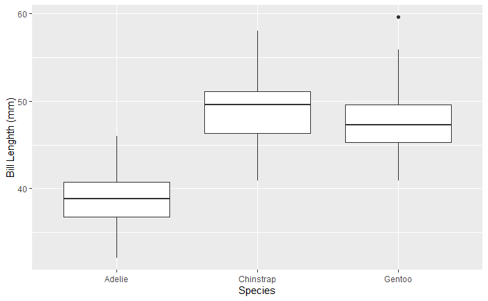

```r
ggplot(penguins)+
  aes(x = species, y = bill_length_mm)+
  geom_boxplot()+
  labs(x = "Species",
       y = "Bill Lenghth (mm)")
```

Each box represents 50% of data per specific species. The horizontal line represents the middle value of the stored data set. The whiskers on either side of the box mark the positions beyond which data values are normally deemed to be outliers. In our case there is only one outlier in Gentoo species. In each case, we can see fair distribution around the median.

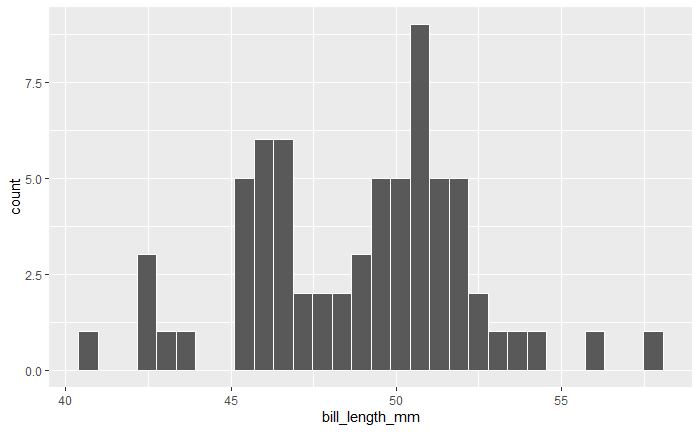

```r
penguins %>%
  drop_na(bill_length_mm) %>%
  filter(species == "Chinstrap") %>%
  ggplot(aes(x = bill_length_mm)) +
  geom_histogram(col = "white")
```

It’s difficult to say clearly, but Chinstrap’s bill length distribution shows some evidence of being bimodal.

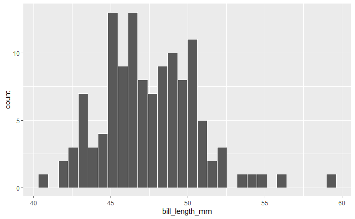

```r
penguins %>%
  drop_na(bill_length_mm) %>%
  filter(species == "Gentoo") %>%
  ggplot(aes(x = bill_length_mm)) +
  geom_histogram(col = "white")
```

Again, it isn’t easy to say clearly, but Gentoo’s bill length distribution looks to be slightly right skewed.

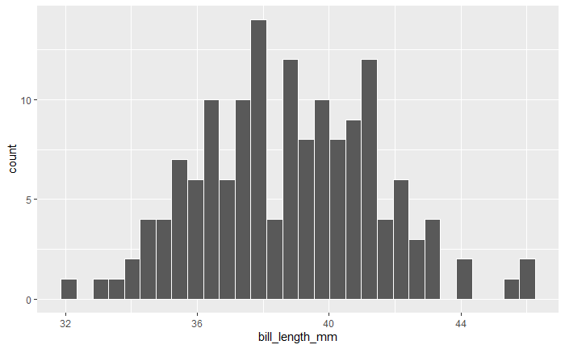

```r
penguins %>%
  drop_na(bill_length_mm) %>%
  filter(species == "Adelie") %>%
  ggplot(aes(x = bill_length_mm)) +
  geom_histogram(col = "white")
```

In the case of the Adelie species bill length, we can see normal distribution but there isn’t a clear peak in the middle.

Distribution shown using a bot plot for all three species:

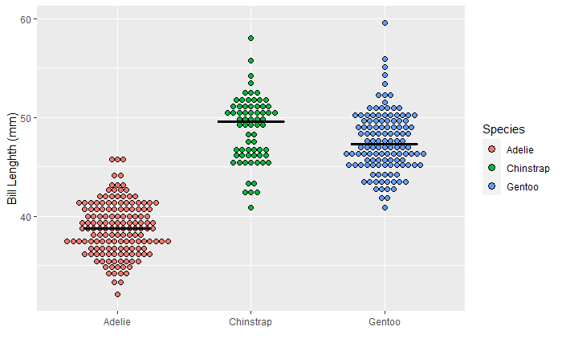

```r
ggplot(data = penguins, aes(y = bill_length_mm, x = species)) + # Move y and x here so than they can be used in stat_*
    geom_dotplot(aes(fill = species),   # Use fill = Species here not in ggplot()
                 binaxis = "y",         # which axis to bin along
                 binwidth = 0.6,        # Minimal difference considered diffeerent
                 stackdir = "center"    # Centered
                 ) +
    stat_summary(fun = median, fun.min = median, fun.max = median,
                 geom = "crossbar", width = 0.5)+
  labs(x = "",
       y = "Bill Lenghth (mm)",
       fill = "Species")
```

```r
penguins %>%
  drop_na(bill_length_mm) %>%
  group_by(species) %>%
  summarise(IQR = IQR(bill_length_mm))
```

| species | IQR |
| --- | --- |
| Adelie | 4.000 |
| Chinstrap | 4.725 |
| Gentoo | 4.250 |

```r
penguins %>%
  drop_na(bill_length_mm) %>%
  group_by(species) %>%
  summarise(
    Q1 = quantile(bill_length_mm, 0.25),
    Q2 = quantile(bill_length_mm, 0.5),
    Q3 = quantile(bill_length_mm, 0.75),
    IQR = Q3 - Q1
  )
```

| species | Q1 | Q2 | Q3 | IQR |
| --- | --- | --- | --- | --- |
| Adelie | 36.75 | 38.80 | 40.750 | 4.000 |
| Chinstrap | 46.35 | 49.55 | 51.075 | 4.725 |
| Gentoo | 45.30 | 47.30 | 49.550 | 4.250 |

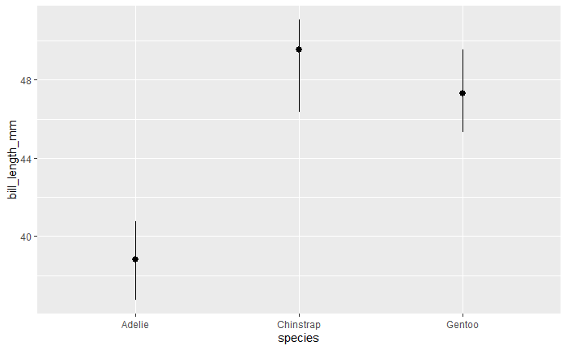

```r
ggplot(penguins) +
  geom_pointrange(aes(x = species, y = bill_length_mm),
                  stat = "summary",
                  fun.min = function(z) {quantile(z,0.25)},
                  fun.max = function(z) {quantile(z,0.75)},
                  fun = median)
```

SUMMARY STATISTICS

— Mean & Median —

```r
penguins %>%
  drop_na(bill_length_mm) %>%
  group_by(species) %>%
  summarise(mean = mean(bill_length_mm),
            median = median(bill_length_mm),
            difference = mean(bill_length_mm) - median(bill_length_mm))
```

[output not shown]

Median length of the bill between penguin species (Adelie, Chinstrap, Gentoo) is 38.80 mm, 49.55 mm, 47.30 mm respectively.

Median and mean values of the bill length hardly differ for Adelie penguin species.

— Spread (Standard Deviation) —

```r
penguins %>%
  drop_na(bill_length_mm) %>%
  group_by(species) %>%
  summarise(standard_deviation = sd(bill_length_mm))
```

[output not shown]

— Skewness —

```r
library(e1071)

penguins %>%
  drop_na(bill_length_mm) %>%
  group_by(species) %>%
  summarise(skewness = skewness(bill_length_mm, type = 1))
```

[output not shown]

HYPOTHESIS TEST & PROBABILITY

TASK: Perform a suitable hypothesis test to check whether the mean bill length of Gentoo is significantly longer than the mean bill length of Adelie.

critical value = 0.05

H0: μ bill(Gentoo) - μ bill(Adelie) = 0 Ha: μ bill(Gentoo) - μ bill(Adelie) > 0

```r
library(infer)

penguins <- penguins %>%
  drop_na(bill_length_mm) %>%
  filter(!species == 'Chinstrap')

penguins %>%
  group_by(species) %>%
  summarise(n = n())
```

| species | n |
| --- | --- |
| Adelie | 151 |
| Gentoo | 123 |

Size of both samples is similar.

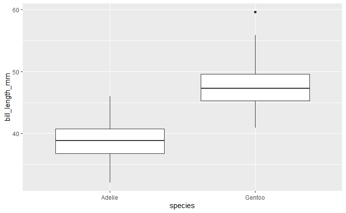

```r
penguins %>%
  ggplot(aes(x = species, y = bill_length_mm))+
  geom_boxplot()
```

Next we use permutation to generate the null distribution.

Under H0 (H0: μ bill(Gentoo) - μ bill(Adelie) = 0) the pengiun species would have no bearing on the bill length, i.e. the species and the bill length are independent. There wouldn’t be difference between groups.

Using permutation we randomly shuffle the species labels and we lose any relationship there was between species and bill length.

```r
null_distribution <- penguins %>%
  specify(bill_length_mm ~ species) %>%
  hypothesize(null = "independence") %>%
  generate(reps = 1000, type = "permute") %>%
  calculate(stat = "diff in means", order = c("Gentoo", "Adelie"))
```

```
Dropping unused factor levels Chinstrap from the supplied explanatory variable 'species'.
```

```r
head(null_distribution)
```

```
Response: bill_length_mm (numeric)
Explanatory: species (factor)
Null Hypothesis: independence
```

| replicate | stat |
| --- | --- |
| 1 | -0.15429925 |
| 2 | -0.64851128 |
| 3 | 0.85477844 |
| 4 | 0.37974479 |
| 5 | -0.29592419 |
| 6 | 0.01388036 |

```r
observed_stat <- penguins %>%
  specify(bill_length_mm ~ species) %>%
  calculate(stat = "diff in means", order = c("Gentoo", "Adelie"))
```

```
Dropping unused factor levels Chinstrap from the supplied explanatory variable 'species'.
```

```r
observed_stat
```

```
Response: bill_length_mm (numeric)
Explanatory: species (factor)
```

| stat |
| --- |
| 8.713487 |

From Ha (Ha: μ bill(Gentoo) - μ bill(Adelie) > 0) we see that this is a one-tailed test because alternative is that the difference is greater than zero.

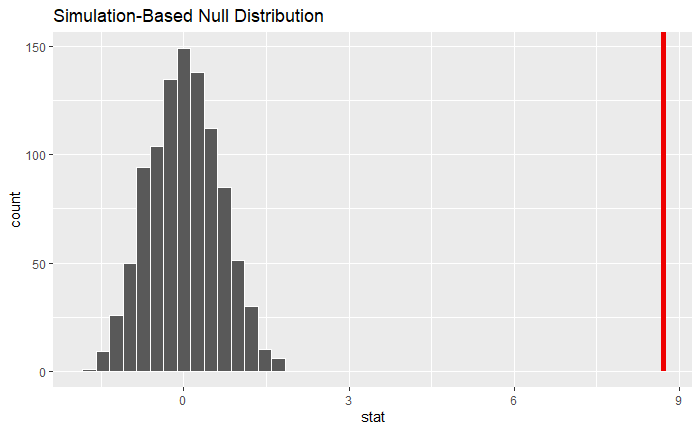

```r
null_distribution %>%
  visualise()+
  shade_p_value(obs_stat = observed_stat, direction = "greater")
```

From graph we can see that there would be extremely low probability of getting a more extreme value than ours under null hypothesis H0.

We can also see that our observed statistic lies outside of the distribution on right hand side.

```r
p_value <- null_distribution %>%
  get_p_value(obs_stat = observed_stat, direction = "greater")
```

```
Please be cautious in reporting a p-value of 0. This result is an approximation based on the number of `reps` chosen in the `generate()` step. See `?get_p_value()` for more information.
```

```r
p_value
```

| p_value |
| --- |
| 0 |

By calculating p-value, we see that it is less than critical value of 0.05 and so we reject the null hypothesis in favour of the alternative hypothesis. We can conclude that we have found enough evidence in our data to suggest that the mean bill length of Gentoo is significantly longer than the mean bill length of Adelie.